# Regression Models (Motor Trend Project)

Nutan Sahoo

21 September 2017

## Executive Summary

The purpose of this project is to explore the impact of a set of variables like horsepower, transmission configuration, engine cylinder configuration, etc. on the mileage `mpg` (Miles per Gallon). In particular we have the following objectives:—

1. To find which one of Automatic or Manual Transmission is better for `mpg`.
2. To Quantify the `mpg` difference b/w auto and manual transmissions.
3. To come up with a model to predict the mileage of a given car.
4. To find how a 1000lbs increase in car’s weight will change the fuel efficiency.

## Exploratory Analysis

We plot various box plots to visualise the distribution of `mpg` by various groups of the categorical variable.[^1] In plot-1 **(see appendix for all plots)** we see that the `mpg` of cars with automatic transmission is much lower than manual. We can check if the difference b/w their mean values are statistically significant through a two-samples independent t-test.

```r
aggregate(mpg~am, data = mtcars, mean)
```

```
##   am      mpg
## 1  0 17.14737
## 2  1 24.39231
```

```r
t.test(mpg~am, data=mtcars)
```

```
##
##  Welch Two Sample t-test
##
## data:  mpg by am
## t = -3.7671, df = 18.332, p-value = 0.001374
## alternative hypothesis: true difference in means is not equal to 0
## 95 percent confidence interval:
##  -11.280194  -3.209684
## sample estimates:
## mean in group 0 mean in group 1
##        17.14737        24.39231
```

**p value <0.05**, we reject the null hypothesis that the true mean difference is equal to zero. Hence, the difference is statistically significant and the cars with automatic transmission have a lower `mpg` on an average. Plot-2 shows that generally, `mpg` of cars with `S` engine configuration is much higher. We can confirm this using a t-test as shown above.

```r
t.test(mpg~vs, data= mtcars)
```

```
##
##  Welch Two Sample t-test
##
## data:  mpg by vs
## t = -4.6671, df = 22.716, p-value = 0.0001098
## alternative hypothesis: true difference in means is not equal to 0
## 95 percent confidence interval:
##  -11.462508  -4.418445
## sample estimates:
## mean in group 0 mean in group 1
##        16.61667        24.55714
```

```r
##t = -4.6671, df = 22.716, p-value = 0.0001098
```

```r
head(mtcars,3)
```

```
##                mpg cyl disp  hp drat    wt  qsec vs am gear carb
## Mazda RX4     21.0   6  160 110 3.90 2.620 16.46  0  1    4    4
## Mazda RX4 Wag 21.0   6  160 110 3.90 2.875 17.02  0  1    4    4
## Datsun 710    22.8   4  108  93 3.85 2.320 18.61  1  1    4    1
```

```r
dim(mtcars)
```

```
## [1] 32 11
```

```r
names(mtcars)
```

```
##  [1] "mpg"  "cyl"  "disp" "hp"   "drat" "wt"   "qsec" "vs"   "am"   "gear"
## [11] "carb"
```

```r
#install.packages("caTools")
library(caTools)
set.seed(88)       #to fix the result that we get as we get different results everytime we run it

spl = sample(1:nrow(data), size=0.85* nrow(data))

train = data[spl,]

test = data[-spl,]
#this is the method for splitting the data set into training and test data when the outcome variable is
#continuous
```

```r
mtcars1<- mtcars[-(28:32), ] #the training set
test_data<- mtcars[28:32, ]  #test data set
test_data
```

```
##                 mpg cyl  disp  hp drat    wt qsec vs am gear carb
## Lotus Europa   30.4   4  95.1 113 3.77 1.513 16.9  1  1    5    2
## Ford Pantera L 15.8   8 351.0 264 4.22 3.170 14.5  0  1    5    4
## Ferrari Dino   19.7   6 145.0 175 3.62 2.770 15.5  0  1    5    6
## Maserati Bora  15.0   8 301.0 335 3.54 3.570 14.6  0  1    5    8
## Volvo 142E     21.4   4 121.0 109 4.11 2.780 18.6  1  1    4    2
```

## Regression Analysis

We have graphically seen that Manual is better for `mpg`. Now we will qantify the difference between them.

```r
mtcars1$cyl<- factor(mtcars1$cyl)
mtcars1$vs<- factor(mtcars1$vs)
mtcars1$am<- factor(mtcars1$am)
mtcars1$carb<- factor(mtcars1$carb)
mtcars1$gear<- factor(mtcars1$gear)
```

There are various methods for choosing a subset of variables for the best regression model which can explain variability in response variable well. There are 2 classes of algorithms for that:—

1. All possible regression approach
2. sequential selection
   1. forward selection
   2. backward selection

### Selecting the Best Model

```r
#install.packages("MASS")
library(MASS)
stepAIC(lm(mpg~., mtcars1), direction = "both") #direction can be forward, backward or both
```

```
## Start:  AIC=58.36
## mpg ~ cyl + disp + hp + drat + wt + qsec + vs + am + gear + carb
##
##        Df Sum of Sq     RSS    AIC
## - cyl   2    0.5244  77.711 54.543
## - qsec  1    1.3899  78.577 56.842
## - am    1    2.0239  79.211 57.059
## - vs    1    3.3084  80.495 57.494
## <none>               77.187 58.361
## - wt    1    6.1828  83.369 58.441
## - hp    1    6.2913  83.478 58.476
## - gear  2   13.0445  90.231 58.577
## - carb  3   21.9188  99.105 59.109
## - disp  1   10.0829  87.270 59.675
## - drat  1   24.4139 101.601 63.781
##
## Step:  AIC=54.54
## mpg ~ disp + hp + drat + wt + qsec + vs + am + gear + carb
##
##        Df Sum of Sq     RSS    AIC
## - qsec  1     0.975  78.686 52.880
## - am    1     2.272  79.983 53.322
## - vs    1     3.685  81.396 53.794
## <none>               77.711 54.543
## - gear  2    14.013  91.724 55.019
## - wt    1     8.006  85.717 55.191
## - hp    1     9.495  87.206 55.656
## - disp  1    13.237  90.948 56.790
## + cyl   2     0.524  77.187 58.361
## - carb  3    36.381 114.092 58.912
## - drat  1    28.307 106.018 60.930
##
## Step:  AIC=52.88
## mpg ~ disp + hp + drat + wt + vs + am + gear + carb
##
##        Df Sum of Sq     RSS    AIC
## - am    1     2.925  81.611 51.865
## - vs    1     3.430  82.116 52.032
## <none>               78.686 52.880
## - wt    1     7.356  86.042 53.293
```

[output cut: 24 more lines]

```
## Step:  AIC=50.06
## mpg ~ disp + hp + drat + wt + gear + carb
##
##        Df Sum of Sq     RSS    AIC
## <none>               82.191 50.057
## - hp    1     7.949  90.140 50.549
## - gear  2    16.535  98.726 51.006
## + qsec  1     0.784  81.406 51.798
## + vs    1     0.580  81.611 51.865
## - wt    1    12.873  95.064 51.985
## + am    1     0.075  82.116 52.032
## - disp  1    17.622  99.812 53.301
## + cyl   2     0.091  82.100 54.027
## - drat  1    40.417 122.608 58.855
## - carb  3    61.085 143.276 59.061
```

```
##
## Call:
## lm(formula = mpg ~ disp + hp + drat + wt + gear + carb, data = mtcars1)
##
## Coefficients:
## (Intercept)         disp           hp         drat           wt
##     6.43785      0.03444     -0.03613      5.56520     -2.27712
##       gear4        gear5        carb2        carb3        carb4
##     4.49717      2.95981     -4.03391     -1.42888     -7.24308
```

```r
m1<- lm(mpg ~ disp + hp + drat + wt + vs + am + gear + carb, data=mtcars1)
#checking for multicollinearity using vif and clorrelation chart
#install.packages("car")
library(car)
vif(m1)
```

```
##           GVIF Df GVIF^(1/(2*Df))
## disp  58.92572  1        7.676309
## hp    23.34290  1        4.831449
## drat  14.24762  1        3.774602
## wt    22.09888  1        4.700944
## vs    24.57621  1        4.957440
## am    23.80195  1        4.878724
## gear  36.26722  2        2.454023
## carb 144.39082  3        2.290463
```

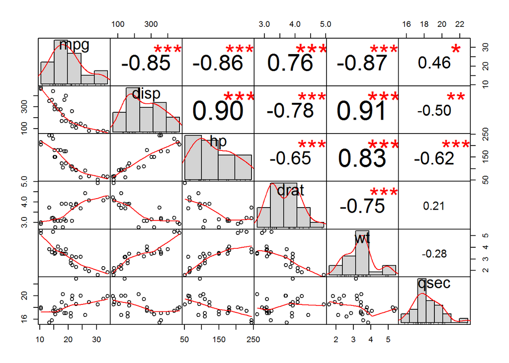

```r
#install.packages("PerformanceAnalytics")
library(PerformanceAnalytics)
chart.Correlation(mtcars1[,c(1,3,4,5,6,7)], histogram =T)
```

The variance inflation factor (VIF), which assesses how much the variance of an estimated regression coefficient increases if your predictors are correlated. If no factors are correlated, the VIFs will all be 1. A VIF between 5 and 10 indicates high correlation that may be problematic. And if the VIF goes above 10, you can assume that the regression coefficients are poorly estimated due to multicollinearity. Remove highly correlated predictors from the model. If you have two or more factors with a high VIF, remove one from the model. Because they supply redundant information, removing one of the correlated factors usually doesn’t drastically reduce the R-squared. Consider using stepwise regression, best subsets regression, or specialized knowledge of the data set to remove these variables.

We remove `disp` as it is highly correlated with all the other regressors along with other regressors which had high vif. We fit various other models and select the best of them:

```r
m2<- lm(mpg~ hp+drat+wt+am+carb-1, mtcars1)
extractAIC(m2)
```

```
## [1]  8.00000 51.25171
```

```r
summary(m2)$coef
```

```
##           Estimate Std. Error      t value    Pr(>|t|)
## hp    -0.023422257 0.01556769 -1.504543172 0.148884027
## drat   4.979435055 1.74005818  2.861648600 0.009984374
## wt    -0.003874243 1.15347572 -0.003358756 0.997355121
## am0    7.775902513 8.60531624  0.903616124 0.377513564
## am1    9.979994455 8.74368339  1.141394765 0.267887780
## carb2 -2.127666831 1.36934339 -1.553786172 0.136734494
## carb3 -2.531807306 1.92848074 -1.312850705 0.204870209
## carb4 -5.842635235 2.02749628 -2.881699602 0.009555014
```

```r
#the coef are not significant and vif is also somewhat high
```

```r
m9<-  lm(mpg~am+wt, mtcars1)
m6<- lm(mpg~am+wt+hp, mtcars1)
anova(m6,m9)   #it is significant.
```

```
## Analysis of Variance Table
##
## Model 1: mpg ~ am + wt + hp
## Model 2: mpg ~ am + wt
##   Res.Df    RSS Df Sum of Sq     F   Pr(>F)
## 1     23 154.23
## 2     24 212.61 -1    -58.38 8.706 0.007174 **
## ---
## Signif. codes:  0 '***' 0.001 '**' 0.01 '*' 0.05 '.' 0.1 ' ' 1
```

```r
m7<- lm(mpg~am+wt+hp+cyl, mtcars1)
anova(m6,m7);  #not significant according to anova
```

```
## Analysis of Variance Table
##
## Model 1: mpg ~ am + wt + hp
## Model 2: mpg ~ am + wt + hp + cyl
##   Res.Df    RSS Df Sum of Sq      F Pr(>F)
## 1     23 154.23
## 2     21 126.14  2     28.09 2.3382 0.1211
```

```r
summary(m6)
```

```
##
## Call:
## lm(formula = mpg ~ am + wt + hp, data = mtcars1)
##
## Residuals:
##     Min      1Q  Median      3Q     Max
## -3.6144 -1.5918 -0.3638  1.1406  5.5011
##
## Coefficients:
##             Estimate Std. Error t value Pr(>|t|)
## (Intercept) 32.79946    2.88463  11.370 6.43e-11 ***
## am1          2.63214    1.60467   1.640  0.11455
## wt          -2.23388    1.03965  -2.149  0.04242 *
## hp          -0.04513    0.01530  -2.951  0.00717 **
## ---
## Signif. codes:  0 '***' 0.001 '**' 0.01 '*' 0.05 '.' 0.1 ' ' 1
##
## Residual standard error: 2.59 on 23 degrees of freedom
## Multiple R-squared:  0.8416, Adjusted R-squared:  0.8209
## F-statistic: 40.72 on 3 and 23 DF,  p-value: 2.295e-09
```

```r
vif(m6)
```

```
##       am       wt       hp
## 2.161742 4.201016 3.160674
```

```r
extractAIC(m6) #variance inflation factor and AIC look good.
```

```
## [1]  4.00000 55.05088
```

```r
#final model
m6<- lm(mpg~am+wt+hp-1, mtcars1)
summary(m6)
```

```
##
## Call:
## lm(formula = mpg ~ am + wt + hp - 1, data = mtcars1)
##
## Residuals:
##     Min      1Q  Median      3Q     Max
## -3.6144 -1.5918 -0.3638  1.1406  5.5011
##
## Coefficients:
##     Estimate Std. Error t value Pr(>|t|)
## am0 32.79946    2.88463  11.370 6.43e-11 ***
## am1 35.43160    1.90375  18.612 2.31e-15 ***
## wt  -2.23388    1.03965  -2.149  0.04242 *
## hp  -0.04513    0.01530  -2.951  0.00717 **
## ---
## Signif. codes:  0 '***' 0.001 '**' 0.01 '*' 0.05 '.' 0.1 ' ' 1
##
## Residual standard error: 2.59 on 23 degrees of freedom
## Multiple R-squared:  0.9869, Adjusted R-squared:  0.9847
## F-statistic: 434.1 on 4 and 23 DF,  p-value: < 2.2e-16
```

```r
#all coef are significant.
confint(m6, level = 0.95)
```

```
##           2.5 %      97.5 %
## am0 26.83215463 38.76676260
## am1 31.49339554 39.36979756
## wt  -4.38455441 -0.08320047
## hp  -0.07677241 -0.01348965
```

Let’s check how accurately it can predict the mileage of the car in the `test_data`.

```r
test_data$cyl<- factor(test_data$cyl)
test_data$vs<- factor(test_data$vs)
test_data$am<- factor(test_data$am)
test_data$carb<- factor(test_data$carb)
test_data$gear<- factor(test_data$gear)


predict(m6, test_data) ; test_data
```

```
##   Lotus Europa Ford Pantera L   Ferrari Dino  Maserati Bora     Volvo 142E
##       26.95193       16.43561       21.34583       12.33776       24.30214
```

```
##                 mpg cyl  disp  hp drat    wt qsec vs am gear carb
## Lotus Europa   30.4   4  95.1 113 3.77 1.513 16.9  1  1    5    2
## Ford Pantera L 15.8   8 351.0 264 4.22 3.170 14.5  0  1    5    4
## Ferrari Dino   19.7   6 145.0 175 3.62 2.770 15.5  0  1    5    6
## Maserati Bora  15.0   8 301.0 335 3.54 3.570 14.6  0  1    5    8
## Volvo 142E     21.4   4 121.0 109 4.11 2.780 18.6  1  1    4    2
```

```r
1-(abs(predict(m6, test_data)-test_data[1]))/test_data[1]
```

```
##                      mpg
## Lotus Europa   0.8865768
## Ford Pantera L 0.9597713
## Ferrari Dino   0.9164555
## Maserati Bora  0.8225173
## Volvo 142E     0.8643862
```

```r
#comparing predictions through mean and standard deviation of accuracy
mean((1-(abs(predict(m6, test_data)-test_data[1]))/test_data[1])[,1]);mean((1-(abs(predict(m7,
test_data)-test_data[1]))/test_data[1])[,1])
```

```
## [1] 0.8899414
```

```
## [1] 0.9041645
```

```r
sd((1-(abs(predict(m6, test_data)-test_data[1]))/test_data[1])[,1]);sd((1-(abs(predict(m7,
   test_data)-test_data[1]))/test_data[1])[,1])
```

```
## [1] 0.05193654
```

```
## [1] 0.07878624
```

Predictions from m6 and the actual mileage of the cars in test data are very close with an average accuracy of abput 89%; model m6 is parsimonious and interpretable too.

### Checking basic assumptions of regression

```r
res<- m6$residuals
shapiro.test(res)
```

```
##
##  Shapiro-Wilk normality test
##
## data:  res
## W = 0.95114, p-value = 0.2285
```

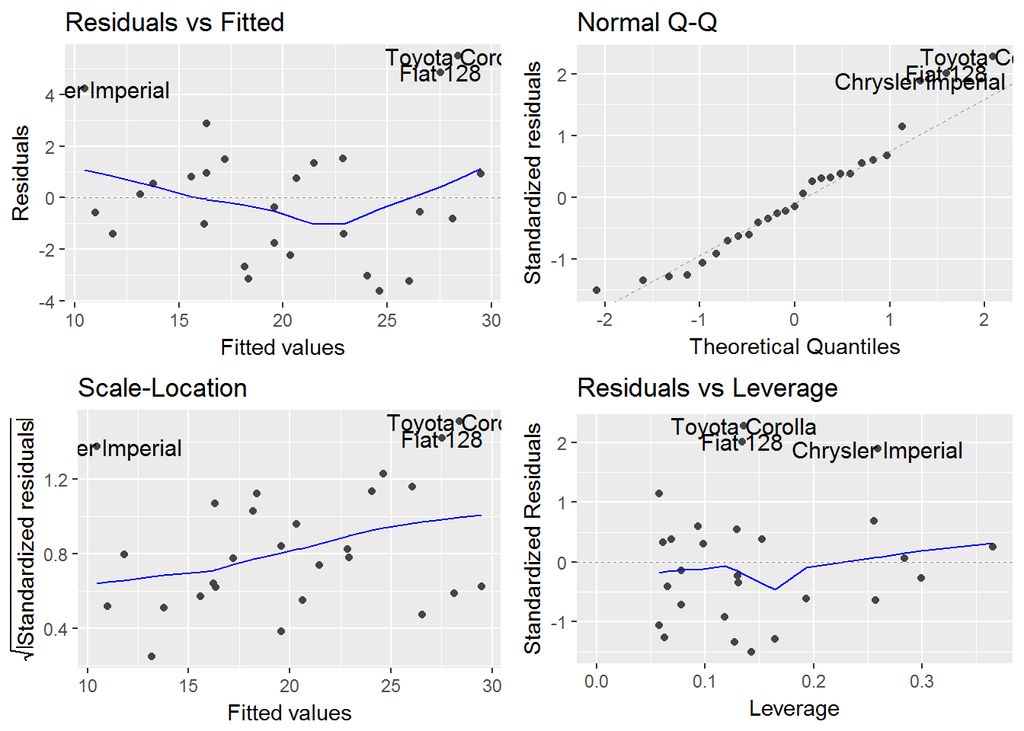

```r
#install.packages("ggfortify")
library(ggfortify)
autoplot(m6, label.size=4)
```

**p>0.05** hence we fail to reject the null hypothesis that residuals are normally distributed. By looking at diagnostic plots, we can say that the residuals are homoscedastic. The scatter points in QQ Plot also seem to lie on the line, thereby confirming their normality. Basic assumptions of regression are met.

We can finally, say that **compared to cars which had automatic transmission(0) we would expect mileage of cars with manual transmission(1) 2.6 miles per gallon more on average given values of other regressor variables remain same**. By looking at the coefficient of the weight variable in the final model, we can conclude that a 1000lbs increase in the weight a car will decrease the mileage by 2.234 miles per gallon.

## Appendix

This section includes all the above mentioned Plots.

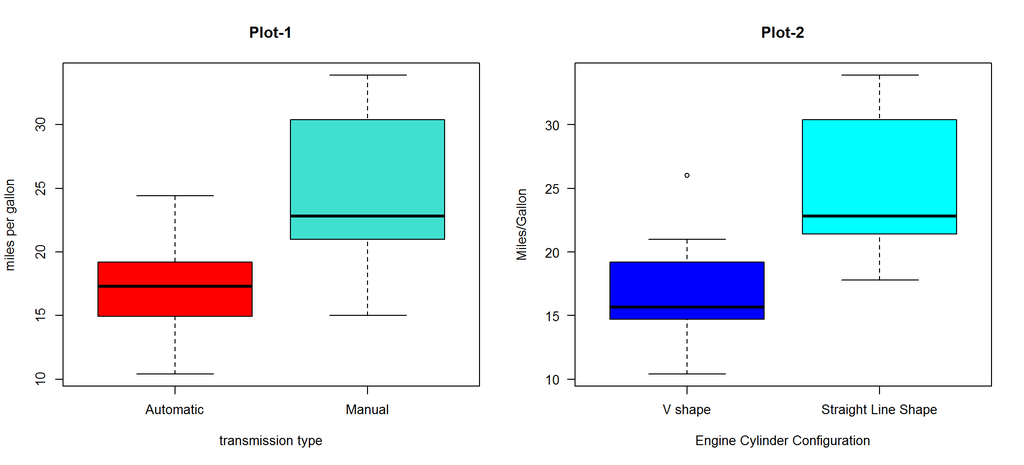

```r
layout(matrix(c(1,2,1,2),2,2, byrow = TRUE))
boxplot(mpg~am,data=mtcars,col=c("red", "turquoise"),xlab="transmission type",ylab="miles per gallon",
        names= c("Automatic","Manual"),main="Plot-1")
boxplot(mpg~vs, data= mtcars, col=c(4,"cyan"), xlab="Engine Cylinder Configuration",
        ylab="Miles/Gallon", las=TRUE, names= c("V shape", "Straight Line Shape"), main="Plot-2")
```

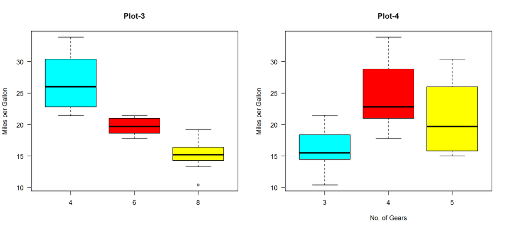

```r
layout(matrix(c(1,2,1,2),2,2, byrow = T))
boxplot(mpg~cyl, data= mtcars, col=c("cyan",42,23),
        ylab="Miles per Gallon", las=TRUE, main="Plot-3")
boxplot(mpg~gear, data= mtcars, col=c("cyan",42,23), xlab="No. of Gears",
        ylab="Miles per Gallon", las=T, main= "Plot-4")
```

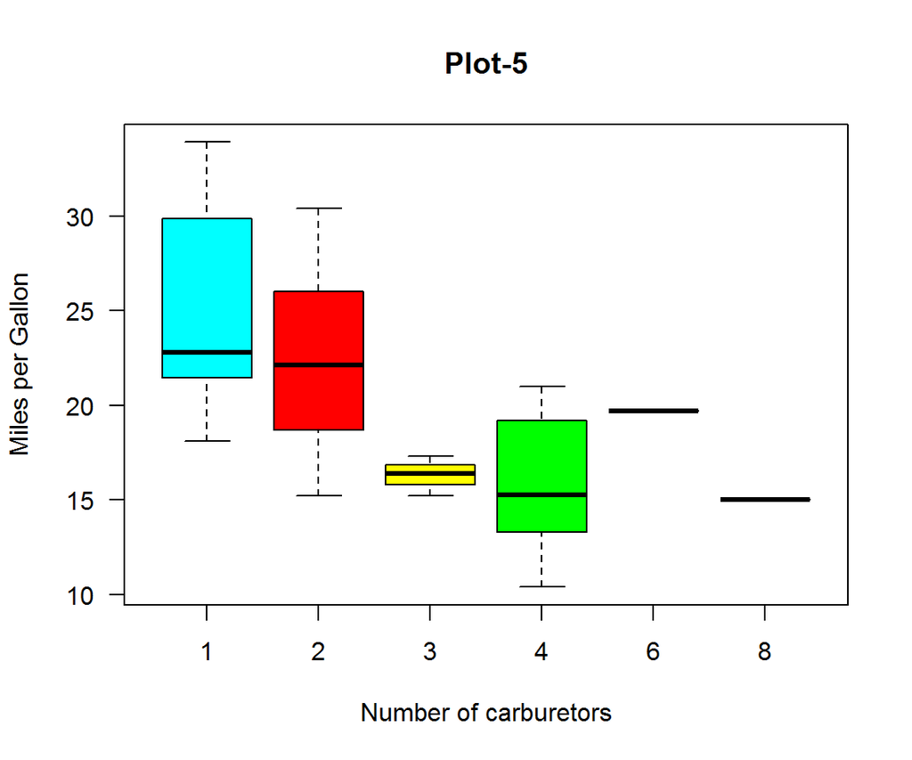

```r
boxplot(mpg~carb, data= mtcars, col=c("cyan",42,23,"green",600), xlab="Number of carburetors",
        ylab="Miles per Gallon", las=T, main="Plot-5")
```

[^1]: **All plots given in appendix**
[^2]: Since, data set is very small, I have just taken the last five(i.e. 15%) rows in the test set